# Simple Regression Analysis Page

Kinito Solutions

September 11, 2016

# OLS-Ordinary least squares

# LinearModel Digression

Note that the lm-function, basically, does nothing else than generating a vector of values of the dependent variable y and a matrix of explanatory variables x. If the model contains a constant, a vector of ones will be added to the matrix x. After that function uses the standard estimation formula (x’x)^{-1}x’y to estimate the coefficients.

```r
#, echo=FALSE}
library("foreign");
ceosal1 <- read.dta("Data/ceosal1.dta");
print("LinearModel Digression");
```

```
## [1] "LinearModel Digression"
```

```r
y <- matrix(ceosal1[,"salary"],ncol=1);
x <- as.matrix(cbind(1,ceosal1[,"roe"]));
solve(t(x)%*%x)%*%t(x)%*%y;
```

```
##           [,1]
## [1,] 963.19134
## [2,]  18.50119
```

# Linear Model

Now you can perform your first regression in R and estimate the effect of the return on equity on the salary of a CEO. For this purpose we use the lm function, where “lm” stands for “linear model”. Its first argument is the regression model followed by further options. The tilde between “salary” and “roe” indicates that salary is the dependent variable and roe is the independent variable, it indicates a “relation”. R automatically uses a constant, except you tell it not to do so by adding -1 to the formula.

```r
library("foreign");
ceosal1 <- read.dta("Data/ceosal1.dta");
linearModel <- lm(salary ~ roe, data=ceosal1);
summary(linearModel);
```

```
##
## Call:
## lm(formula = salary ~ roe, data = ceosal1)
##
## Residuals:
##     Min      1Q  Median      3Q     Max
## -1160.2  -526.0  -254.0   138.8 13499.9
##
## Coefficients:
##             Estimate Std. Error t value Pr(>|t|)
## (Intercept)   963.19     213.24   4.517 1.05e-05 ***
## roe            18.50      11.12   1.663   0.0978 .
## ---
## Signif. codes:  0 '***' 0.001 '**' 0.01 '*' 0.05 '.' 0.1 ' ' 1
##
## Residual standard error: 1367 on 207 degrees of freedom
## Multiple R-squared:  0.01319,    Adjusted R-squared:  0.008421
## F-statistic: 2.767 on 1 and 207 DF,  p-value: 0.09777
```

```r
linearModel;
```

```
##
## Call:
## lm(formula = salary ~ roe, data = ceosal1)
##
## Coefficients:
## (Intercept)          roe
##       963.2         18.5
```

```r
names(linearModel);
```

```
##  [1] "coefficients"  "residuals"     "effects"       "rank"
##  [5] "fitted.values" "assign"        "qr"            "df.residual"
##  [9] "xlevels"       "call"          "terms"         "model"
```

# LinearModel Subset

```r
aDataFrame <- data.frame(roe=ceosal1$salary[1:15],
                         salary=ceosal1$salary[1:15],
                         salaryhat=NA,
                         uhat=NA);
aDataFrame <- tibble::as_data_frame(aDataFrame);
head(aDataFrame);
```

```
## Source: local data frame [6 x 4]
##
##     roe salary salaryhat  uhat
##   <int>  <int>     <lgl> <lgl>
## 1  1095   1095        NA    NA
## 2  1001   1001        NA    NA
## 3  1122   1122        NA    NA
## 4   578    578        NA    NA
## 5  1368   1368        NA    NA
## 6  1145   1145        NA    NA
```

```r
aDataFrame$salaryhat <- linearModel$fitted.values[1:15];
aDataFrame$uhat <- linearModel$resid[1:15];
aDataFrame;
```

```
## Source: local data frame [15 x 4]
##
##      roe salary salaryhat        uhat
##    <int>  <int>     <dbl>       <dbl>
## 1   1095   1095  1224.058 -129.058071
## 2   1001   1001  1164.854 -163.854261
## 3   1122   1122  1397.969 -275.969216
## 4    578    578  1072.348 -494.348338
## 5   1368   1368  1218.508  149.492288
## 6   1145   1145  1333.215 -188.215063
## 7   1078   1078  1266.611 -188.610785
## 8   1094   1094  1264.761 -170.760660
## 9   1237   1237  1157.454   79.546207
## 10   833    833  1449.773 -616.772523
## 11   567    567  1442.372 -875.372056
## 12   933    933  1459.023 -526.023116
## 13  1339   1339  1237.009  101.991102
## 14   937    937  1375.768 -438.767778
## 15  2011   2011  2004.808    6.191886
```

# LinearModel Example

```r
myDataFrame <- read.csv("Data/regression_auto.csv")
head(myDataFrame)
```

```
##   make mpg weight weight1 price foreign repairs length
## 1  AMC  22   2930    2.93  4099       0       3    186
## 2  AMC  17   3350    3.35  4749       0       3    173
## 3  AMC  22   2640    2.64  3799       0       3    168
## 4 Audi  17   2830    2.83  9690       1       5    189
## 5 Audi  23   2070    2.07  6295       1       3    174
## 6  BMW  25   2650    2.65  9735       1       4    177
```

```r
attach(myDataFrame)

# Define variables
Y <- cbind(mpg)
X1 <- cbind(weight1)
X <- cbind(weight1, price, foreign)

# Descriptive statistics
summary(Y)
```

```
##       mpg
##  Min.   :14.00
##  1st Qu.:17.25
##  Median :21.00
##  Mean   :20.92
##  3rd Qu.:23.00
##  Max.   :35.00
```

```r
summary(X1)
```

```
##     weight1
##  Min.   :2.020
##  1st Qu.:2.643
##  Median :3.200
##  Mean   :3.099
##  3rd Qu.:3.610
##  Max.   :4.330
```

```r
summary(X)
```

```
##     weight1          price          foreign
##  Min.   :2.020   Min.   : 3299   Min.   :0.0000
##  1st Qu.:2.643   1st Qu.: 4466   1st Qu.:0.0000
##  Median :3.200   Median : 5146   Median :0.0000
##  Mean   :3.099   Mean   : 6652   Mean   :0.2692
##  3rd Qu.:3.610   3rd Qu.: 8054   3rd Qu.:0.7500
##  Max.   :4.330   Max.   :15906   Max.   :1.0000
```

```r
# Correlation among variables
cor(Y, X)
```

```
##        weight1      price   foreign
## mpg -0.8081609 -0.4384618 0.4003376
```

```r
# Plotting data on a scatter diagram
plot(Y ~ X1, data = myDataFrame)

# Simple linear regression
simpleLinearRegression <- lm(Y ~ X1)
summary(simpleLinearRegression)
```

```
##
## Call:
## lm(formula = Y ~ X1)
##
## Residuals:
##     Min      1Q  Median      3Q     Max
## -5.4123 -1.6073 -0.1043  0.9261  8.1072
##
## Coefficients:
##             Estimate Std. Error t value Pr(>|t|)
## (Intercept)  38.0665     2.6112  14.578 2.02e-13 ***
## X1           -5.5315     0.8229  -6.722 5.93e-07 ***
## ---
## Signif. codes:  0 '***' 0.001 '**' 0.01 '*' 0.05 '.' 0.1 ' ' 1
##
## Residual standard error: 2.86 on 24 degrees of freedom
## Multiple R-squared:  0.6531, Adjusted R-squared:  0.6387
## F-statistic: 45.19 on 1 and 24 DF,  p-value: 5.935e-07
```

```r
confint(simpleLinearRegression, level=0.95)
```

```
##                 2.5 %    97.5 %
## (Intercept) 32.677256 43.455664
## X1          -7.229797 -3.833196
```

```r
anova(simpleLinearRegression)
```

```
## Analysis of Variance Table
##
## Response: Y
##           Df Sum Sq Mean Sq F value    Pr(>F)
## X1         1 369.57  369.57  45.189 5.935e-07 ***
## Residuals 24 196.28    8.18
## ---
## Signif. codes:  0 '***' 0.001 '**' 0.01 '*' 0.05 '.' 0.1 ' ' 1
```

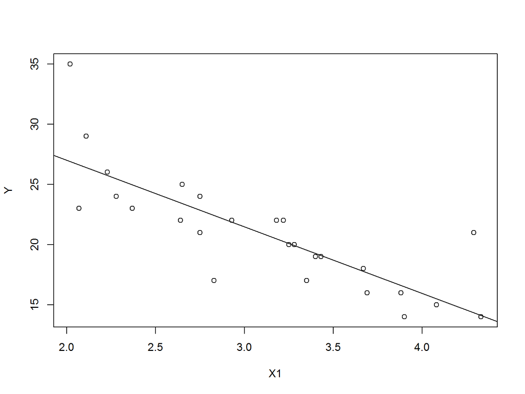

```r
# Plotting regression line
abline(simpleLinearRegression)
```

```r
# Predicted values for dependent variable
predValuesDepVarY <- fitted(simpleLinearRegression)
summary(predValuesDepVarY)
```

```
##    Min. 1st Qu.  Median    Mean 3rd Qu.    Max.
##   14.12   18.10   20.37   20.92   23.45   26.89
```

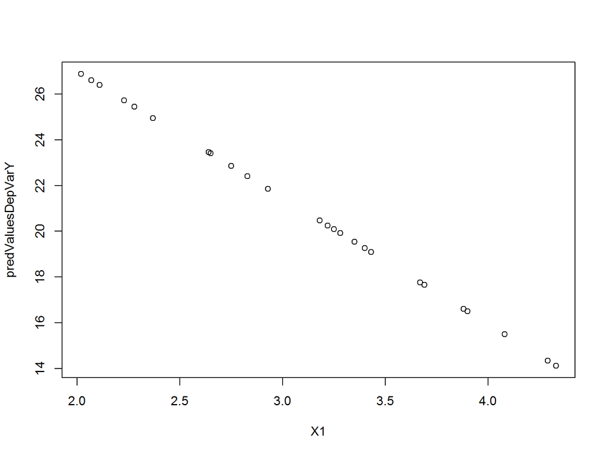

```r
plot(predValuesDepVarY ~ X1)
```

```r
# Regression residuals
regressionResiduals <- resid(simpleLinearRegression)
summary(regressionResiduals)
```

```
##    Min. 1st Qu.  Median    Mean 3rd Qu.    Max.
## -5.4120 -1.6070 -0.1043  0.0000  0.9261  8.1070
```

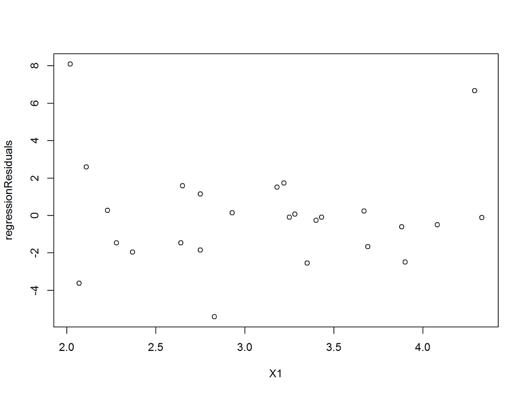

```r
plot(regressionResiduals ~ X1)
```